# tidystats

6/3/2018

## Part 1: The why

## Science 2.0

In the last several years we have seen many improvements to how we do science. We now:

- Replicate more
- Pre-register more
- Share more

## Science 2.0

In the last several years we have seen many improvements to how we do science. We now:

- Replicate more
- Pre-register more
- Share more

But I think we can do better.

## PDF prisons

Although we share more, we mostly share our **data** and the **scripts** needed to analyze that data.

What we do not share in this manner, is the **output** of our analyses. These can only be found in our papers.

## PDF prisons

Although we share more, we mostly share our **data** and the **scripts** needed to analyze that data.

What we do not share in this manner, is the **output** of our analyses. These can only be found in our papers.

Resulting in what I call PDF prisons.

[figure not shown]

## Additionally…

We see the Results section not just as a collection of statistics, but also a story, aimed at a reader with limited time and motivation.

- Creating a conflict between being comprehensive (reporting everything) and providing a streamlined story

And we do not have a good workflow solution that allows us to easily organize the output of statistical analyses and communicate this.

- Meaning we have to manually copy over statistical results into or out of a manuscript

## Two problems in statistics reporting

I think these observations are responsible for two problems in statistics reporting:

1. Not all statistics are reported
2. Not all statistics are *correctedly* reported

## Incomplete reporting

Often not all statistics are reported. In many different ways.

Estimates range from 4% to 24.1%. (Bakker & Wicherts, 2011; Caperos, Olmos, & Pardo, 2016)

Or even 83.8% in the case of correlations. (Caperos et al., 2016)

## Incomplete reporting

These estimates are likely to be underestimations, as the authors only focussed on specific tests.

## Incomplete reporting

These estimates are likely to be underestimations, as the authors only focussed on specific tests.

Bakker and Wicherts, p. 667:

> "We did not consider *χ2*, *t*, and *F* tests that were used in regression analysis or model fitting, because statistical tests of regressions are often not presented fully"

## Incomplete reporting

These estimates are likely to be underestimations, as the authors only focussed on specific tests.

Bakker and Wicherts, p. 667:

> "We did not consider *χ2*, *t*, and *F* tests that were used in regression analysis or model fitting, because statistical tests of regressions are often not presented fully"

Additionally, I'm not sure how the authors dealt with the following examples:

## Incomplete reporting example #1

Summarizing statistics

> "We found no other main or interaction effects (**all *F*s < 0.66, all *p*s > .42**). The model examining assessments of men’s warmth revealed no main or interaction effects (**all *F*s < 0.3, all *p*s > .58**)."

## Incomplete reporting example #2

Arbitrary cut-off points

> "In contrast, participants’ support for group-based dominance did not differ between the low (*M* = 2.21, *SD* = 1.23) and moderate (*M* = 2.20, *SD* = 1.24) social mobility conditions, *F*(1, 193) = 0.001, *p* > .250, *d* = .01."

## Incomplete reporting example #3

Regression tables without exact *p*-values, confidence intervals, etc.

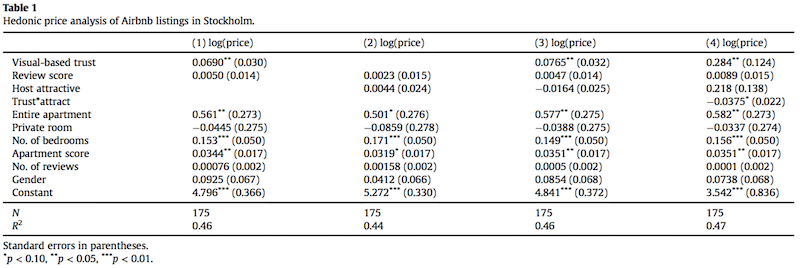

## Incomplete reporting

Additional information such as effect sizes or confidence intervals are still rarely reported. (Cumming et al., 2007; Hoekstra, Finch, Kiers, & Johnson, 2006; Vacha-Haase, Nilsson, Reetz, Lance, & Thompson, 2000)

## Incomplete reporting

So, there are quite some examples of incomplete statistics reporting.

Some of these are clearly incorrect (e.g., ommitting *df*s in an *F*-test).

## Incomplete reporting

So, there are quite some examples of incomplete statistics reporting.

Some of these are clearly incorrect (e.g., ommitting *df*s in an *F*-test).

But other scenario's make sense. Reporting 10 regression analyses with all relevant output **IS** overkill.

## Incomplete reporting

So, there are quite some examples of incomplete statistics reporting.

Some of these are clearly incorrect (e.g., ommitting *df*s in an *F*-test).

But other scenario's make sense. Reporting 10 regression analyses with all relevant output **IS** overkill.

We can use a better solution.

## Incorrect reporting

Inaccuracies in statistics reporting are prevalent. (Nuijten et al., 2017; Nuijten, Hartgerink, Assen, Epskamp, & Wicherts, 2015)

In psychology, about **half of all articles** contain at least one inconsistent result in which the reported *p*-value does not correspond with the accompanying test statistic and degrees of freedom.

## Incorrect reporting causes

Probable reasons for these errors are (Bakker & Wicherts, 2011; Lakens, 2015):

- Typos
- Copy-paste errors
- Incorrect rounding
- Incorrect use of '<' instead of '='
- Not mentioning the test was one-sided

## Incorrect reporting causes

Probable reasons for these errors are (Bakker & Wicherts, 2011; Lakens, 2015):

- Typos
- Copy-paste errors
- Incorrect rounding
- Incorrect use of '<' instead of '='
- Not mentioning the test was one-sided

Note: Most of these causes are not nefarious. They're just human error.

## Possible solutions

- Check data and scripts
- Statcheck

## Check data and scripts

Very time consuming.

And reviewing is already pro-bono, so making it more effortful will be met with resistance.

## Check data and scripts

Very time consuming.

And reviewing is already pro-bono, so making it more effortful will be met with resistance.

Plus, what if you discover a mistake? You're still going to use your human-hands to correct it.

Bakker and Wicherts (2011):

> We searched all the articles for statistical results and imported them to a separate Excel file by hand.

[figure not shown]

## statcheck limitations

However, statcheck cannot prevent all mistakes

- it is good (really good!), but not perfect
- it cannot extract all statistics (e.g., from tables)
  - extracts about 61% of the statistics (Nuijten, Assen, Hartgerink, Epskamp, & Wicherts, 2017)

## Silliness

I think it is silly to have to go through the effort of *text extraction* to get at the output of statistical analyses.

## What is a better solution?

Add an extra step in the data analysis workflow:

- *Before* writing up the results, first organize the output of the statistical analyses in a separate text file
  - Storing statistics outside of the manuscript frees up the manuscript to be more streamlined and it's easy to share a text file
- Then *use* this text file to write up the results
  - An organized output file can be used to automate statistics reporting

## New data analysis workflow

1. Data preparation
   - Reading in data
   - Preparing data for data analysis
   - Saving prepared data
2. Data analysis
   - Test pre-registered hypotheses
   - Exploration
3. **Create statistics output file**
4. Write up results

## Interim-conclusion

## Interim-conclusion

There are two statistics-output related problems:

1. Not all statistics are reported
2. Not all statistics are *correctedly* reported

I believe we should work on structuring the output of statistical analyses in such a manner that we can share *all* output, outside of our manuscript, and *use* it to, without error, write up the results in our manuscript.

## Part 2: The how

## Challenge

How to combine the output of different analyses in a structured, sensible manner?

## Challenge

How to combine the output of different analysis in a structured, sensible manner?

**Solution**: Make it tidy (Wickham, 2014)

> Tidy datasets are easy to manipulate, model and visualize, and have a specific structure: each variable is a column, each observation is a row, and each type of observational unit is a table.

## Tidy statistics output

Each row is a statistic

Each column is a useful variable (e.g., the kind of statistic)

Each table is a statistical analysis

## Tidy statistics output

Each row is a statistic

Each column is a useful variable (e.g., the kind of statistic)

Each table is a statistical analysis

**Example**:

|  | statistic | value | method | notes |
| --- | --- | --- | --- | --- |
| 1 | t | -1.86 | Welch Two Sample t-test | two.sided test |
| 2 | df | 17.78 | Welch Two Sample t-test | two.sided test |
| 3 | p | 0.08 | Welch Two Sample t-test | two.sided test |
| 4 | 95% CI lower | -3.37 | Welch Two Sample t-test | two.sided test |
| 5 | 95% CI upper | 0.21 | Welch Two Sample t-test | two.sided test |

## Solution

A tidy data structure enables us to combine the output of different kinds of output, into a single file.

So, what we need is way to grab the output of a statistical analysis, make it tidy, and combine it with other analyses.

## Solution

A tidy data structure enables us to combine the output of different kinds of output, into a single file.

So, what we need is way to grab the output of a statistical analysis, make it tidy, and combine it with other analyses.

…this is what **tidystats** does.

## tidystats

*tidystats* is an R package to easily create a text file containing the output of statistical models.

This enables researchers to:

1. Easily share *all* statistics
2. Easily report statistics

## How does it work?

The idea is that you start with an empty list, and whenever you conduct an analysis that you want to share the results of, you add it to the list.

At the end of data analysis, you take this list and simply save it as a text file.

This text file is a comma separated data file, which can be shared and read by anyone.

## Installing tidystats

```r
# Install from CRAN
install.packages("tidystats")

# Install latest version
library(devtools)
install_github("willemsleegers/tidystats")
```

## Setup

Start by loading the package, followed by creating an empty list to store results into.

```r
# Load package
library(tidystats)

# Create empty list
results <- list()
```

## Example: t-test

Let's analyse Student's sleep data.

| ID | group | extra |
| --- | --- | --- |
| 1 | 1 | 0.7 |
| 2 | 1 | -1.6 |
| 3 | 1 | -0.2 |
| 4 | 1 | -1.2 |
| 5 | 1 | -0.1 |
| 6 | 1 | 3.4 |
| 7 | 1 | 3.7 |
| 8 | 1 | 0.8 |
| 9 | 1 | 0 |
| 10 | 1 | 2 |

[output cut: 10 more lines]

## Example: t-test

```r
t.test(extra ~ group, data = sleep, var.equal = TRUE)
```

```
##
##  Two Sample t-test
##
## data:  extra by group
## t = -1.8608, df = 18, p-value = 0.07919
## alternative hypothesis: true difference in means is not equal to 0
## 95 percent confidence interval:
##  -3.363874  0.203874
## sample estimates:
## mean in group 1 mean in group 2
##            0.75            2.33
```

## Example: t-test

To add the output, use the `add_stats()` function. It takes the output as the first argument, the list as the second argument, and then a unique identifier.

```r
# Run the t-test and store the results in a variable
model1 <- t.test(extra ~ group, data = sleep, var.equal = TRUE)

# Add the output to the list
results <- add_stats(model1, results, identifier = "sleep_t_test")
```

## More examples

```r
# Correlation
results <- cor.test(sleep$extra, as.numeric(sleep$group)) %>%
  add_stats(results, identifier = "sleep_correlation")

# ANOVA
results <- aov(extra ~ group, data = sleep) %>%
  add_stats(results, identifier = "sleep_anova")

# Regression
results <- lm(extra ~ group, data = sleep) %>%
  add_stats(results, identifier = "sleep_regression")
```

I use the piping symbol (%>%) to directly put the output in `add_stats()`.

## Save results

Convert the list to a text file with the `write_stats()` function.

```r
write_stats(results, "data/results.csv")
```

Under the hood it converts the list to a data frame and then saves it using `write_csv()`.

## Results overview

| identifier | term_nr | term | statistic | value | method |
| --- | --- | --- | --- | --- | --- |
| sleep_t_test |  |  | mean in group 1 | 0.75 | Two Sample t-test |
| sleep_t_test |  |  | mean in group 2 | 2.33 | Two Sample t-test |
| sleep_t_test |  |  | t | -1.86081346748685 | Two Sample t-test |
| sleep_t_test |  |  | df | 18 | Two Sample t-test |
| sleep_t_test |  |  | p | 0.0791867142159382 | Two Sample t-test |
| sleep_t_test |  |  | 95% CI lower | -3.3638740322876 | Two Sample t-test |
| sleep_t_test |  |  | 95% CI upper | 0.203874032287599 | Two Sample t-test |
| sleep_t_test |  |  | null value | 0 | Two Sample t-test |
| sleep_correlation |  |  | cor | 0.401662608156429 | Pearson's product-moment correlation |
| sleep_correlation |  |  | t | 1.86081346748685 | Pearson's product-moment correlation |

[output cut: 29 more lines]

## Real-time example

Do we have time for an extra example?